# Datacube processing I

Advanced Geospatial Data Processing for Social Scientists

Dennis Abel & Stefan Jünger

2026-06-10

## Now

| Day | Time | Title |
| --- | --- | --- |
| June 9 | 10:00–11:15 | Introduction |
| June 9 | 11:15–11:30 | Coffee Break |
| June 9 | 11:30–13:00 | Raster data in R |
| June 9 | 13:00–14:00 | Lunch Break |
| June 9 | 14:00–15:15 | Raster data processing |
| June 9 | 15:15–15:30 | Coffee Break |
| June 9 | 15:30–17:00 | Graphical display of raster data in maps |
| June 10 | 10:00–11:15 | Datacube processing I |
| June 10 | 11:15–11:30 | Coffee Break |
| June 10 | 11:30–13:00 | Datacube processing II & API access |
| June 10 | 13:00–14:00 | Lunch Break |
| June 10 | 14:00–15:15 | Data integration and linking (with survey data) |
| June 10 | 15:15–15:30 | Coffee Break |
| June 10 | 15:30–17:00 | Outlook and open session with own application |

## Datacubes

Yesterday, we worked with single layers of raster data. Today, we turn towards the more complex **raster stacks or datacubes**. Essentially we add one or more dimension(s) to our data object. This increases complexity - for humans and machines.

Our goal for today is to:

- Understand the **logic of raster stacks and datacubes**
- Be able to **stack multiple raster layers** into a coherent raster stack or datacube
- Be able to navigate and process the **spatial and temporal dimensions**
- Familiarize ourselves with the `stars` and `terra` packages for raster processing

## Datacubes

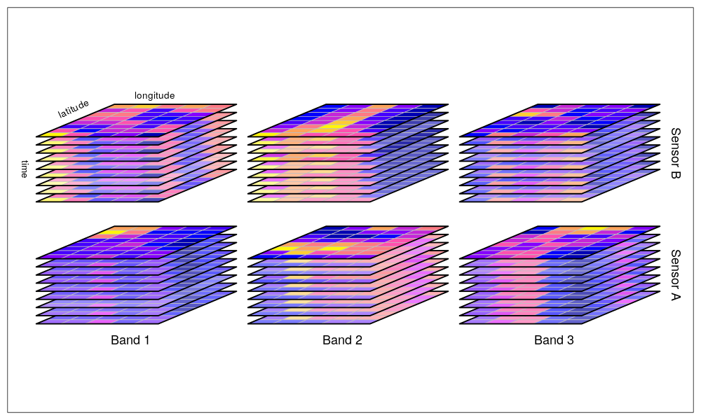

[Source](https://raw.githubusercontent.com/r-spatial/stars/master/images/cube2.png)

## Most important EOD packages 📦

If you want to do anything in `R`, you need to use functions, and functions are provided through packages.

[`terra`](https://rspatial.github.io/terra/index.html) (and its predecessor `raster`) by Robert Hijmans is probably the most commonly used package for raster data in `R` (and equally relevant for vector data).

Methods for vector data include geometric operations such as intersect and buffer. Raster methods include local, focal, global, zonal and geometric operations. The predict and interpolate methods facilitate the use of regression type (interpolation, machine learning) models for spatial prediction.

The authors have produced a very extensive [tutorial](https://rspatial.org/) which is basically a textbook for spatial data science in R.

[figure not shown]

## Most important EOD packages 📦

If you want to do anything in `R`, you need to use functions, and functions are provided through packages.

[figure not shown]

Source: [Allison Horst (2018)](https://allisonhorst.com/allison-horst)

[`stars`](https://r-spatial.github.io/stars/index.html) by Edzer Pebesma is equally useful when handling spatiotemporal arrays (datacubes).

This R package provides classes and methods for reading, manipulating, plotting and writing such data cubes, to the extent that there are proper formats for doing so.

The `stars` syntax follows the logic of the [`sf`](https://r-spatial.github.io/sf/)-package (also by Edzer Pebesma) and together they can be seen as the emergence of a “spatial tidyverse”.

Edzer Pebesma’s and Roger Bivand’s [Spatial Data Science](https://r-spatial.org/book/) textbook is THE go-to resource for learning the `sf` and `stars` syntax.

## Similarities and differences between `terra` and `stars`

- With `terra`, we create **three-dimensional stacks of raster layers**
- There is no need for a coherent logic for what this third dimension constitutes - as long as the single raster layers **fit to each other** (spatial extent, resolution, CRS)
- In contrast, `stars` objects can be **multi-dimensional** and can store many variables (attributes) along the three dimensions x, y and time
- Major difference: `terra` doesn’t treat the third dimension (time or band) as a “dimension” in the same way `stars` does.
- Time is encoded via layer names or separate metadata in `terra` objects — you manage it manually.

Informally we will call `SpatRaster` objects created with `terra` “raster stacks” and `stars` objects “raster cubes”.

## Stacking raster layers

We will start by manually creating our raster stacks/cubes by combining several layers. We will first show our `terra`-approach and afterwards replicate the process with `stars`. These steps include:

- Combination of separate layers into one object
- Adjustments to metadata and global attributes like:
  - Time dimension
  - CRS

The output will be a clean raster stack/cube for further processing/analysis.

## `terra` approach: stacking raster layers

We load four layers of population data for California for the years 2017-2020.

```r
CA_pop_2017 <- terra::rast("./data/worldpop/US-CA_ppp_2017_1km.tif")
CA_pop_2018 <- terra::rast("./data/worldpop/US-CA_ppp_2018_1km.tif")
CA_pop_2019 <- terra::rast("./data/worldpop/US-CA_ppp_2019_1km.tif")
CA_pop_2020 <- terra::rast("./data/worldpop/US-CA_ppp_2020_1km.tif")

class(CA_pop_2017)
```

```
[1] "SpatRaster"
attr(,"package")
[1] "terra"
```

```r
CA_pop_2017
```

```
class       : SpatRaster
size        : 1136, 1234, 1  (nrow, ncol, nlyr)
resolution  : 0.008333333, 0.008333333  (x, y)
extent      : -124.4179, -114.1346, 32.54125, 42.00792  (xmin, xmax, ymin, ymax)
coord. ref. : lon/lat WGS 84 (EPSG:4326)
source      : US-CA_ppp_2017_1km.tif
name        : US-CA_ppp_2017_1km
```

## `terra` approach: stacking raster layers

We can simply concatenate (`c()`) the layers to create a raster stack.

```r
CA_pop_stack <- c(CA_pop_2017, CA_pop_2018, CA_pop_2019, CA_pop_2020)

class(CA_pop_stack)
```

```
[1] "SpatRaster"
attr(,"package")
[1] "terra"
```

```r
CA_pop_stack
```

```
class       : SpatRaster
size        : 1136, 1234, 4  (nrow, ncol, nlyr)
resolution  : 0.008333333, 0.008333333  (x, y)
extent      : -124.4179, -114.1346, 32.54125, 42.00792  (xmin, xmax, ymin, ymax)
coord. ref. : lon/lat WGS 84 (EPSG:4326)
sources     : US-CA_ppp_2017_1km.tif
              US-CA_ppp_2018_1km.tif
              US-CA_ppp_2019_1km.tif
              US-CA_ppp_2020_1km.tif
names       : US-CA_p~017_1km, US-CA_p~018_1km, US-CA_p~019_1km, US-CA_p~020_1km
```

## `terra` approach: stacking raster layers

We can integrate reading and stacking into one step by providing a list of raster layers to the `terra::rast()` command.

```r
# Stacking more automated
files <- list.files("./data/worldpop", pattern = "US-CA_ppp_20(17|18|19|20)_1km\\.tif$", full.names = TRUE)
CA_pop_stack <- terra::rast(files)

CA_pop_stack
```

```
class       : SpatRaster
size        : 1136, 1234, 4  (nrow, ncol, nlyr)
resolution  : 0.008333333, 0.008333333  (x, y)
extent      : -124.4179, -114.1346, 32.54125, 42.00792  (xmin, xmax, ymin, ymax)
coord. ref. : lon/lat WGS 84 (EPSG:4326)
sources     : US-CA_ppp_2017_1km.tif
              US-CA_ppp_2018_1km.tif
              US-CA_ppp_2019_1km.tif
              US-CA_ppp_2020_1km.tif
names       : US-CA_p~017_1km, US-CA_p~018_1km, US-CA_p~019_1km, US-CA_p~020_1km
```

## `terra` approach: stacking raster layers

You know that we can utilize the base `R` `plot` function to visualize `SpatRaster` objects. This is also true for raster stacks.

```r
# Have a first glance at the data
terra::plot(CA_pop_stack)
```

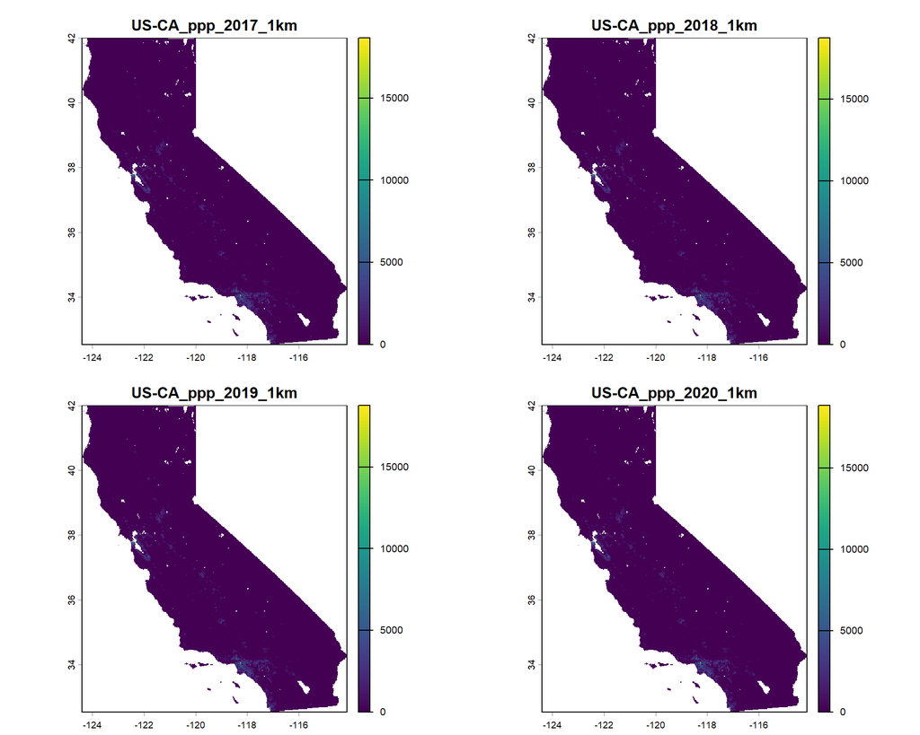

## `terra` approach: stacking raster layers

Dates can be assigned to the layers. This will effectively create a new attribute in the object **IN ADDITION** to the name of the variable.

```r
layer_dates <- as.Date(paste0(2017:2020, "-01-01"))
time(CA_pop_stack) <- layer_dates

CA_pop_stack
```

```
class       : SpatRaster
size        : 1136, 1234, 4  (nrow, ncol, nlyr)
resolution  : 0.008333333, 0.008333333  (x, y)
extent      : -124.4179, -114.1346, 32.54125, 42.00792  (xmin, xmax, ymin, ymax)
coord. ref. : lon/lat WGS 84 (EPSG:4326)
sources     : US-CA_ppp_2017_1km.tif
              US-CA_ppp_2018_1km.tif
              US-CA_ppp_2019_1km.tif
              US-CA_ppp_2020_1km.tif
names       : US-CA_p~017_1km, US-CA_p~018_1km, US-CA_p~019_1km, US-CA_p~020_1km
time (days) : 2017-01-01 to 2020-01-01 (4 steps)
```

```r
time(CA_pop_stack)
```

```
[1] "2017-01-01" "2018-01-01" "2019-01-01" "2020-01-01"
```

```r
timeInfo(CA_pop_stack)
```

```
  time step zone
1 TRUE days
```

## `terra` approach: stacking raster layers

When plotting the raster stack, by default the machine understands to access the time attribute, not the names, to label the plots.

```r
# Have a first glance at the data
terra::plot(CA_pop_stack)
```

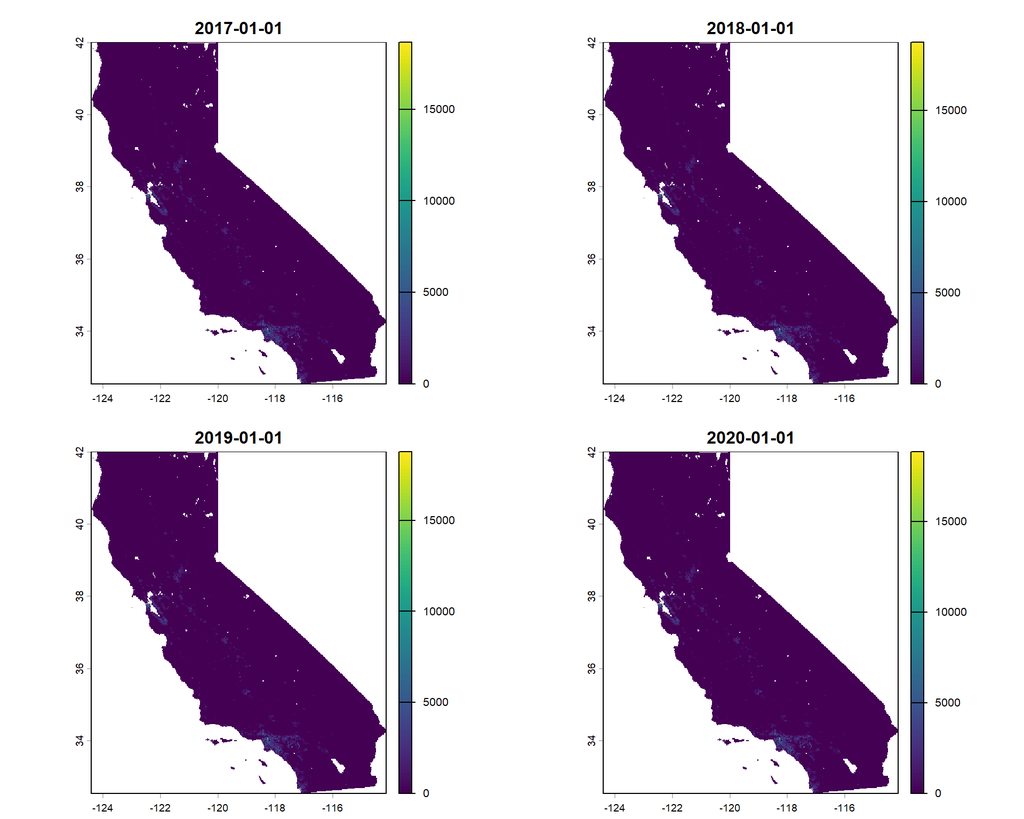

## `terra` approach: stacking raster layers

When defining the time dimension, we can also store the time zone of the date.

```r
layer_posix <- as.POSIXct(layer_dates, tz = "UTC")

time(CA_pop_stack) <- layer_posix

time(CA_pop_stack)
```

```
[1] "2017-01-01 UTC" "2018-01-01 UTC" "2019-01-01 UTC" "2020-01-01 UTC"
```

```r
timeInfo(CA_pop_stack)
```

```
  time    step zone
1 TRUE seconds  UTC
```

## `terra` approach: stacking raster layers

When working with a yearly resolution, it is often consensus to set the date to the first of January. If you want to avoid confusion and explicitly assign only the year, you can do that by adjusting the `tstep=` argument in the `terra::time`-function.

```r
layer_years <- c(2017:2020)
time(CA_pop_stack, tstep = "years") <- layer_years

CA_pop_stack
```

```
class       : SpatRaster
size        : 1136, 1234, 4  (nrow, ncol, nlyr)
resolution  : 0.008333333, 0.008333333  (x, y)
extent      : -124.4179, -114.1346, 32.54125, 42.00792  (xmin, xmax, ymin, ymax)
coord. ref. : lon/lat WGS 84 (EPSG:4326)
sources     : US-CA_ppp_2017_1km.tif
              US-CA_ppp_2018_1km.tif
              US-CA_ppp_2019_1km.tif
              US-CA_ppp_2020_1km.tif
names       : US-CA_p~017_1km, US-CA_p~018_1km, US-CA_p~019_1km, US-CA_p~020_1km
time (years): 2017 to 2020 (4 steps)
```

```r
time(CA_pop_stack)
```

```
[1] 2017 2018 2019 2020
```

```r
timeInfo(CA_pop_stack)
```

```
  time  step zone
1 TRUE years
```

## `terra` approach: stacking raster layers

When working with a yearly resolution, it is often consensus to set the date to the first of January. If you want to avoid confusion and explicitly assign only the year, you can do that by adjusting the `tstep=` argument in the `terra::time`-function.

```r
# Have a first glance at the data
terra::plot(CA_pop_stack)
```

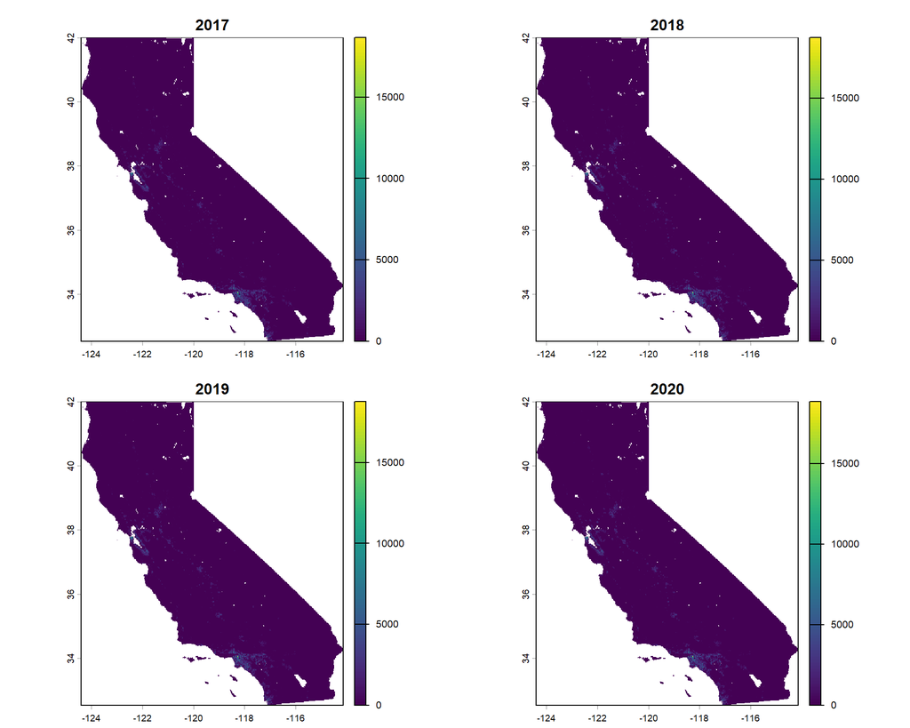

## `terra` approach: stacking raster layers

By default, the variable name is derived from the file-name. We can replace it with a simpler version.

```r
# Adjust variable name
names(CA_pop_stack) <- paste0("pop_", layer_years)

print(CA_pop_stack)
```

```
class       : SpatRaster
size        : 1136, 1234, 4  (nrow, ncol, nlyr)
resolution  : 0.008333333, 0.008333333  (x, y)
extent      : -124.4179, -114.1346, 32.54125, 42.00792  (xmin, xmax, ymin, ymax)
coord. ref. : lon/lat WGS 84 (EPSG:4326)
sources     : US-CA_ppp_2017_1km.tif
              US-CA_ppp_2018_1km.tif
              US-CA_ppp_2019_1km.tif
              US-CA_ppp_2020_1km.tif
names       : pop_2017, pop_2018, pop_2019, pop_2020
time (years): 2017 to 2020 (4 steps)
```

## `terra` approach: stacking raster layers

There are also options to adjust short and long variable names.

```r
# Optional - setting variable names
varnames(CA_pop_stack) <- "population"

longnames(CA_pop_stack) <- "California population estimate (1 km grid)"

print(CA_pop_stack)
```

```
class       : SpatRaster
size        : 1136, 1234, 4  (nrow, ncol, nlyr)
resolution  : 0.008333333, 0.008333333  (x, y)
extent      : -124.4179, -114.1346, 32.54125, 42.00792  (xmin, xmax, ymin, ymax)
coord. ref. : lon/lat WGS 84 (EPSG:4326)
sources     : US-CA_ppp_2017_1km.tif
              US-CA_ppp_2018_1km.tif
              US-CA_ppp_2019_1km.tif
              US-CA_ppp_2020_1km.tif
varnames    : population (California population estimate (1 km grid))
              population (California population estimate (1 km grid))
              population (California population estimate (1 km grid))
              ...
names       : pop_2017, pop_2018, pop_2019, pop_2020
time (years): 2017 to 2020 (4 steps)
```

## `terra` approach: stacking raster layers

Although in practice, we often don’t do it, there is also the option to explicitly set the value unit.

```r
# Setting units
units(CA_pop_stack)
```

```
[1] "" "" "" ""
```

```r
units(CA_pop_stack) <- "count"

units(CA_pop_stack)
```

```
[1] "count" "count" "count" "count"
```

## `terra` approach: stacking raster layers

For a quick glance at the distribution of the data, it is helpful to add minimum and maximum values to the metadata. By default not displayed because first reading raster from disk just creates a pointer object which does not read all cell values.

```r
setMinMax(CA_pop_stack, force=TRUE)

print(CA_pop_stack)
```

```
class       : SpatRaster
size        : 1136, 1234, 4  (nrow, ncol, nlyr)
resolution  : 0.008333333, 0.008333333  (x, y)
extent      : -124.4179, -114.1346, 32.54125, 42.00792  (xmin, xmax, ymin, ymax)
coord. ref. : lon/lat WGS 84 (EPSG:4326)
sources     : US-CA_ppp_2017_1km.tif
              US-CA_ppp_2018_1km.tif
              US-CA_ppp_2019_1km.tif
              US-CA_ppp_2020_1km.tif
varnames    : population (California population estimate (1 km grid))
              population (California population estimate (1 km grid))
              population (California population estimate (1 km grid))
              ...
names       : pop_2017, pop_2018, pop_2019, pop_2020
min values  :     0.00,        0,     0.00,     0.00
max values  : 29224.54,    29316, 29433.52, 29535.46
unit        : count
time (years): 2017 to 2020 (4 steps)
```

## `terra` approach: stacking raster layers

With the `crs`-function, we can directly access the CRS of the object. You can assign a label to the crs of the stack (for example in case it does not have one). **IMPORTANT:** Keep in mind that this **DOES NOT** reproject the data.

```r
crs(CA_pop_stack)
```

```
[1] "GEOGCRS[\"WGS 84\",\n    ENSEMBLE[\"World Geodetic System 1984 ensemble\",\n        MEMBER[\"World Geodetic System 1984 (Transit)\"],\n        MEMBER[\"World Geodetic System 1984 (G730)\"],\n        MEMBER[\"World Geodetic System 1984 (G873)\"],\n        MEMBER[\"World Geodetic System 1984 (G11…
```

```r
# crs(CA_pop_stack) <- "EPSG:4326"
```

## `terra` approach: stacking raster layers

If you want to reproject the data, you can utilize `project` as before. Here, we transform to NAD83 / California Albers (EPSG:3310).

```r
CA_pop_stack <- terra::project(CA_pop_stack,
                               y = "EPSG:3310",
                               method = "bilinear"
                               )

print(CA_pop_stack)
```

```
class       : SpatRaster
size        : 1287, 1168, 4  (nrow, ncol, nlyr)
resolution  : 828.2603, 828.2603  (x, y)
extent      : -415531, 551877.1, -607609.6, 458361.4  (xmin, xmax, ymin, ymax)
coord. ref. : NAD83 / California Albers (EPSG:3310)
source(s)   : memory
names       : pop_2017, pop_2018, pop_2019, pop_2020
min values  :      0.0,     0.00,     0.00,     0.00
max values  :  22052.6, 22123.96, 22208.66, 22285.26
unit        : count
time (years): 2017 to 2020 (4 steps)
```

## `terra` approach: stacking raster layers

If you want to reproject the data, you can utilize `project` as before. Here, we transform to NAD83 / California Albers (EPSG:3310).

```r
# Have a first glance at the data
terra::plot(CA_pop_stack)
```

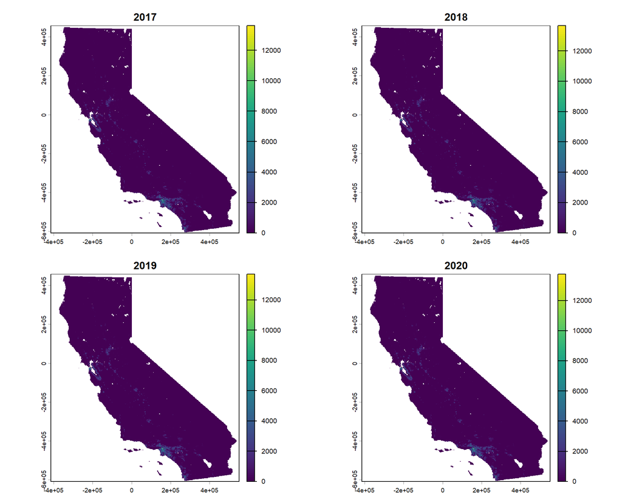

## Note on reprojecting raster data

Reprojecting raster data is fundamentally different from reprojecting vector data:

- Vector data can be transformed and back-transformed **without loss of precision**. The coordinates of points, lines, or polygons are recalculated exactly, and attribute values remain unchanged.
- Raster data, in contrast, requires **resampling**: when reprojected, the original pixel values must be interpolated or aggregated to fit a new grid.
- As a result, every **reprojection** of a raster involves **estimation** and may lead to **changes or smoothing** of the original cell values.
- **Practical advice**: When aligning raster and vector data, **it is usually better to reproject the vector data** onto the raster’s coordinate system — to avoid unnecessary loss or distortion in the raster values.

## `terra::project()` documentation

[interactive chart not shown]

## Note on reprojecting raster data

| Method | Best for |
| --- | --- |
| `near` | categorical, IDs |
| `mode` | categorical |
| `bilinear` | continuous |
| `mean` | continuous, densities, proportions |
| `sum` | counts, totals |
| `median`, `q1`, `q3` | robust summaries |
| `min`, `max` | extremes |
| `cubic`, `cubicspline`, `lanczos` | smooth image-like continuous |

## `terra` approach: stacking raster layers

Now that we have properly prepared variable names and times, we have several options to access single layers or specific cell values.

In the beginning, usage of double `[[i]]` and single `[i]` brackets is a bit confusing.

- `[[i]]` is used for accessing layers based on names and index
- `[i]` generally used for accessing cell values
- **Exception to the rule**: `[i]` also works on layer names and time provided as strings

This generally leads to:

- `your_raster[[layer]]`
- `your_raster[cell]`
- `your_raster[[layer]][cell]`

## `terra` approach: stacking raster layers

Now that we have properly prepared variable names and times, we have several options to access single layers or specific cell values.

Accessing **layers**:

```r
# Indexing by layer index number
# Returns SpatRaster
CA_pop_stack[[1]]
```

```
class       : SpatRaster
size        : 1287, 1168, 1  (nrow, ncol, nlyr)
resolution  : 828.2603, 828.2603  (x, y)
extent      : -415531, 551877.1, -607609.6, 458361.4  (xmin, xmax, ymin, ymax)
coord. ref. : NAD83 / California Albers (EPSG:3310)
source(s)   : memory
name        : pop_2017
min value   :      0.0
max value   :  22052.6
unit        :    count
time (years): 2017
```

```r
# Give me layers 1 to 3
CA_pop_stack[[1:3]]
```

```
class       : SpatRaster
size        : 1287, 1168, 3  (nrow, ncol, nlyr)
resolution  : 828.2603, 828.2603  (x, y)
extent      : -415531, 551877.1, -607609.6, 458361.4  (xmin, xmax, ymin, ymax)
coord. ref. : NAD83 / California Albers (EPSG:3310)
source(s)   : memory
names       : pop_2017, pop_2018, pop_2019
min values  :      0.0,     0.00,     0.00
max values  :  22052.6, 22123.96, 22208.66
unit        : count
time (years): 2017 to 2019 (3 steps)
```

```r
# Give me layers 1 and 3
CA_pop_stack[[c(1,3)]]
```

```
class       : SpatRaster
size        : 1287, 1168, 2  (nrow, ncol, nlyr)
resolution  : 828.2603, 828.2603  (x, y)
extent      : -415531, 551877.1, -607609.6, 458361.4  (xmin, xmax, ymin, ymax)
coord. ref. : NAD83 / California Albers (EPSG:3310)
source(s)   : memory
names       : pop_2017, pop_2019
min values  :      0.0,     0.00
max values  :  22052.6, 22208.66
unit        : count
time (years): 2017 to 2019 (2 steps)
```

```r
# Indexing by layer name
# Returns SpatRaster
CA_pop_stack[["pop_2018"]]
```

```
class       : SpatRaster
size        : 1287, 1168, 1  (nrow, ncol, nlyr)
resolution  : 828.2603, 828.2603  (x, y)
extent      : -415531, 551877.1, -607609.6, 458361.4  (xmin, xmax, ymin, ymax)
coord. ref. : NAD83 / California Albers (EPSG:3310)
source(s)   : memory
name        : pop_2018
min value   :     0.00
max value   : 22123.96
unit        :    count
time (years): 2018
```

```r
# Indexing by time point
# !only single brackets work!
# Returns SpatRaster
CA_pop_stack["2019"]
```

```
class       : SpatRaster
size        : 1287, 1168, 1  (nrow, ncol, nlyr)
resolution  : 828.2603, 828.2603  (x, y)
extent      : -415531, 551877.1, -607609.6, 458361.4  (xmin, xmax, ymin, ymax)
coord. ref. : NAD83 / California Albers (EPSG:3310)
source(s)   : memory
name        : pop_2019
min value   :     0.00
max value   : 22208.66
unit        :    count
time (years): 2019
```

## `terra` approach: stacking raster layers

Now that we have properly prepared variable names and times, we have several options to access single layers or specific cell values.

Accessing **cells**:

```r
# Give me all values
# Returns data.frame
CA_pop_stack[]
```

```
               pop_2017     pop_2018     pop_2019     pop_2020
      [1,]          NaN          NaN          NaN          NaN
      [2,]          NaN          NaN          NaN          NaN
      [3,]          NaN          NaN          NaN          NaN
      [4,]          NaN          NaN          NaN          NaN
      [5,]          NaN          NaN          NaN          NaN
      [6,]          NaN          NaN          NaN          NaN
      [7,]          NaN          NaN          NaN          NaN
      [8,]          NaN          NaN          NaN          NaN
      [9,]          NaN          NaN          NaN          NaN
     [10,]          NaN          NaN          NaN          NaN
     [11,]          NaN          NaN          NaN          NaN
     [12,]          NaN          NaN          NaN          NaN
     [13,]          NaN          NaN          NaN          NaN
     [14,]          NaN          NaN          NaN          NaN
```

[output cut: 24986 more lines]

```r
# Give me values for cell numbers 700,000 for all layers
# Returns data.frame
CA_pop_stack[700000]
```

```
  pop_2017 pop_2018 pop_2019 pop_2020
1 1.652807 1.679097 1.737051 1.726991
```

```r
# Give me values for cell numbers 700,000-700,010 for all layers
# Returns data.frame
CA_pop_stack[700000:700010]
```

```
    pop_2017  pop_2018  pop_2019  pop_2020
1  1.6528070 1.6790969 1.7370507 1.7269908
2  0.8797831 0.9048712 0.9240457 0.9449061
3  4.6530766 4.6990910 4.7851863 4.9210734
4  6.3421636 6.4375587 6.4780517 6.8248892
5  2.6596708 2.6986599 2.7297258 2.9429669
6  0.3505580 0.3522162 0.3630352 0.3871021
7  0.1679804 0.1690340 0.1760728 0.1797919
8  0.3797968 0.3853023 0.3960192 0.4077551
9  1.0326680 1.0474815 1.0648600 1.0850933
10 1.5815146 1.5949552 1.6134428 1.6369106
11 0.6026462 0.6208204 0.6165476 0.6315076
```

```r
# Give me values for cell numbers 700,000 and 700,010 for all layers
CA_pop_stack[c(700000,700010)]
```

```
   pop_2017  pop_2018  pop_2019  pop_2020
1 1.6528070 1.6790969 1.7370507 1.7269908
2 0.6026462 0.6208204 0.6165476 0.6315076
```